# これは最新版の【教材①】です

### ここでは、Pythonの基本的な使い方を説明します

### Pythonを使ったことがない人が、使えるようになることを目指します

```python
# データ解析でよく使うライブラリをインポートします
# 覚える必要はありません、毎回、コピペでOKです！
import pandas as pd
import numpy as np
import seaborn as sns
import matplotlib.pyplot as plt
```

## 1. まずは「0-based numbering」に慣れましょう

```python
# これは「リスト」を作ります
stations = ["Tokyo", "Shinagawa", "Shibuya", "Shinjuku", "Ikebukuro"]
```

```python
# 「stations」を見てみましょう
stations
```

```
['Tokyo', 'Shinagawa', 'Shibuya', 'Shinjuku', 'Ikebukuro']
```

```python
# jupyter notebook外では、print()関数を用いることで、コンソールに出力できます
print(stations)
```

```
['Tokyo', 'Shinagawa', 'Shibuya', 'Shinjuku', 'Ikebukuro']
```

```python
# 0番目の要素を出力
stations[0]
```

```
'Tokyo'
```

```python
# 1番目の要素を出力
stations[1]
```

```
'Shinagawa'
```

```python
# 0番目と1番目の要素を出力
stations[0:2]
```

```
['Tokyo', 'Shinagawa']
```

```python
# 0番目と1番目の要素を出力（より簡潔な記法）
stations[:2]
```

```
['Tokyo', 'Shinagawa']
```

```python
# 1番目、2番目、3番目の要素を出力
stations[1:4]
```

```
['Shinagawa', 'Shibuya', 'Shinjuku']
```

```python
# 最後の要素を出力
stations[-1]
```

```
'Ikebukuro'
```

```python
# 最後から2番目の要素を出力
stations[-2]
```

```
'Shinjuku'
```

```python
# 最後から2番目と最後の要素を出力
stations[-2:]
```

```
['Shinjuku', 'Ikebukuro']
```

## 2. matrixで「0-based numbering」に慣れましょう

```python
matrix = np.array([[1,2,3], [4,5,6], [7,8,9]])
matrix
```

```
array([[1, 2, 3],
       [4, 5, 6],
       [7, 8, 9]])
```

```python
# 0-1行目を出力（一番おすすめ)
matrix[:2, :]
```

```
array([[1, 2, 3],
       [4, 5, 6]])
```

```python
# cを出力する書き方のバリエーション
# matrix[0:2, :]  # ひとつ上と全く同じ
# matrix[:2, ] 　 # ひとつ上と全く同じ
```

```python
# 0-1列目を出力（一番おすすめ)
matrix[:, :2]
```

```
array([[1, 2],
       [4, 5],
       [7, 8]])
```

```python
# 0-1行目、0-1列目を出力
matrix[:2, :2]
```

```
array([[1, 2],
       [4, 5]])
```

```python
# 1-2行目、1-2列目を出力
matrix[1:3, 1:3]
```

```
array([[5, 6],
       [8, 9]])
```

```python
# こう書くことも可能
matrix[1:, 1:]
```

```
array([[5, 6],
       [8, 9]])
```

## 3.「pandas」に慣れましょう

- pandasはデータを効率よく扱うためのライブラリです
- pandasとnumpyと、どちらを使えばいいですか？ややこしいです...
- numpyは「なんでもできる」が「少し難しい」ライブラリ、pandasは「numpyを簡単に効率よく扱う」ためのライブラリ
- 最初は気にせず使ってください！

```python
# まずはデータを読み込んでみましょう
f = "./data/test_data_1.xlsx"
df = pd.read_excel(f)
df
```

|  | sample | sampling_date | is_male | RBC |
| --- | --- | --- | --- | --- |
| 0 | sample1 | 2026-2-10 | True | 200 |
| 1 | sample2 | 2026-2-10 | False | 400 |
| 2 | sample3 | 2026-3-8 | False | 500 |
| 3 | sample4 | 2026-3-8 | True | 400 |

```python
# データの情報を見てみましょう
df.info()
```

```
<class 'pandas.core.frame.DataFrame'>
RangeIndex: 4 entries, 0 to 3
Data columns (total 4 columns):
 #   Column         Non-Null Count  Dtype
---  ------         --------------  -----
 0   sample         4 non-null      object
 1   sampling_date  4 non-null      object
 2   is_male        4 non-null      bool
 3   RBC            4 non-null      int64
dtypes: bool(1), int64(1), object(2)
memory usage: 228.0+ bytes
```

```python
# 要約を見てみましょう
df.describe()
```

|  | RBC |
| --- | --- |
| count | 4.000000 |
| mean | 375.000000 |
| std | 125.830574 |
| min | 200.000000 |
| 25% | 350.000000 |
| 50% | 400.000000 |
| 75% | 425.000000 |
| max | 500.000000 |

```python
# データフレームの大きさを見てみましょう
df.shape
```

```
(4, 4)
```

```python
# データが「ちゃんとした」データかどうかを確認しましょう
# 欠損値がないかを確認します
df.isnull().sum()
```

```
sample           0
sampling_date    0
is_male          0
RBC              0
dtype: int64
```

```python
# 重複行がないかを確認します
df.duplicated().sum()
```

```
np.int64(0)
```

## 4. データの内容に応じて、データフレームを作りましょう

```python
# これは「文字列」「Bool型」「数値」が混じったデータです
f = "./data/test_data_1.xlsx"
df = pd.read_excel(f)
df
```

|  | sample | sampling_date | is_male | RBC |
| --- | --- | --- | --- | --- |
| 0 | sample1 | 2026-2-10 | True | 200 |
| 1 | sample2 | 2026-2-10 | False | 400 |
| 2 | sample3 | 2026-3-8 | False | 500 |
| 3 | sample4 | 2026-3-8 | True | 400 |

```python
# これは「数値のみ」のデータです
f = "./data/test_data_2.tsv"
df = pd.read_table(f, index_col = 0)
df
```

| gene_name | sample1 | sample2 | sample3 | sample4 |
| --- | --- | --- | --- | --- |
| GAPDH | 1000 | 1020 | 950 | 2000 |
| ACTB | 2000 | 2500 | 2600 | 1800 |
| HLA-A | 40 | 30 | 35 | 50 |
| XIST | 100 | 300 | 400 | 200 |

### 説明

- バイオインフォマティクスでは、ざっくりというと、上記のような２種類のデータ行列を扱います
- 違いの一つは「index」の有無です
- 一つ目のデータフレームは「index名」に意味はありません（ただの数字です）
- 二つ目のデータフレームは「index名」と「column名」の両方が重要です

```python
# index名が重要なデータの時は「index_col = 0」を指定します
f = "./data/test_data_2.tsv"
df = pd.read_table(f, index_col = 0)
df
```

| gene_name | sample1 | sample2 | sample3 | sample4 |
| --- | --- | --- | --- | --- |
| GAPDH | 1000 | 1020 | 950 | 2000 |
| ACTB | 2000 | 2500 | 2600 | 1800 |
| HLA-A | 40 | 30 | 35 | 50 |
| XIST | 100 | 300 | 400 | 200 |

```python
# 「index_col = 0」を指定しないとこうなります
# これでは、「文字列」と「数値」が混じったデータとなり、下流の計算でエラーが出る可能性があります
f = "./data/test_data_2.tsv"
df = pd.read_table(f)
df
```

|  | gene_name | sample1 | sample2 | sample3 | sample4 |
| --- | --- | --- | --- | --- | --- |
| 0 | GAPDH | 1000 | 1020 | 950 | 2000 |
| 1 | ACTB | 2000 | 2500 | 2600 | 1800 |
| 2 | HLA-A | 40 | 30 | 35 | 50 |
| 3 | XIST | 100 | 300 | 400 | 200 |

## 5. 大きなデータを読み込んでみましょう

```python
# 大きなデータ
f = "count_matrix.tsv"
df = pd.read_table(f, index_col = 0)
```

```python
# まずは、恐れずに、出力してみます
# jupyter notebookは優秀なので、自動で出力するデータ範囲を限定してくれます
df
```

| gene_name | iPS_1 | iPS_2 | iPS_3 | iPS_4 | iPS_5 | iPS_6 | iPS_7 | iPS_8 | iPS_9 | iPS_10 | ... | iPS_41 | iPS_42 | iPS_43 | iPS_44 | iPS_45 | iPS_46 | iPS_47 | iPS_48 | iPS_49 | iPS_50 |
| --- | --- | --- | --- | --- | --- | --- | --- | --- | --- | --- | --- | --- | --- | --- | --- | --- | --- | --- | --- | --- | --- |
| DDX11L1 | 0 | 0 | 0 | 0 | 0 | 0 | 0 | 0 | 0 | 0 | ... | 0 | 0 | 0 | 0 | 2 | 0 | 0 | 0 | 0 | 0 |
| WASH7P | 203 | 150 | 76 | 214 | 96 | 126 | 112 | 130 | 134 | 114 | ... | 136 | 93 | 143 | 143 | 151 | 199 | 154 | 588 | 98 | 323 |
| MIR6859-1 | 26 | 17 | 2 | 38 | 11 | 16 | 23 | 16 | 28 | 19 | ... | 35 | 23 | 21 | 23 | 32 | 21 | 19 | 51 | 26 | 60 |
| MIR1302-2HG | 0 | 0 | 0 | 0 | 0 | 0 | 1 | 6 | 0 | 0 | ... | 0 | 0 | 0 | 0 | 3 | 0 | 0 | 2 | 0 | 3 |
| FAM138A | 0 | 0 | 0 | 0 | 0 | 0 | 0 | 0 | 0 | 0 | ... | 0 | 0 | 0 | 0 | 0 | 0 | 0 | 0 | 0 | 0 |
| ... | ... | ... | ... | ... | ... | ... | ... | ... | ... | ... | ... | ... | ... | ... | ... | ... | ... | ... | ... | ... | ... |
| CYCSP49 | 0 | 0 | 7 | 0 | 0 | 0 | 0 | 0 | 2 | 4 | ... | 0 | 0 | 0 | 0 | 0 | 0 | 0 | 0 | 0 | 0 |
| SLC25A15P1 | 0 | 0 | 0 | 0 | 0 | 0 | 0 | 0 | 0 | 0 | ... | 0 | 0 | 0 | 0 | 0 | 0 | 0 | 0 | 0 | 0 |
| PARP4P1 | 2 | 4 | 0 | 0 | 6 | 4 | 12 | 0 | 10 | 0 | ... | 0 | 0 | 2 | 10 | 0 | 0 | 6 | 12 | 0 | 0 |
| FAM58CP | 0 | 0 | 0 | 0 | 0 | 0 | 0 | 0 | 0 | 0 | ... | 0 | 0 | 0 | 0 | 0 | 0 | 0 | 0 | 0 | 0 |
| CTBP2P1 | 0 | 0 | 0 | 0 | 0 | 0 | 0 | 0 | 0 | 0 | ... | 0 | 0 | 0 | 0 | 0 | 0 | 0 | 0 | 0 | 0 |

54356 rows × 50 columns

```python
# データの内容を調査します
df.shape  # データフレームの大きさ
```

```
(54356, 50)
```

```python
df.info()
```

```
<class 'pandas.core.frame.DataFrame'>
Index: 54356 entries, DDX11L1 to CTBP2P1
Data columns (total 50 columns):
 #   Column  Non-Null Count  Dtype
---  ------  --------------  -----
 0   iPS_1   54356 non-null  int64
 1   iPS_2   54356 non-null  int64
 2   iPS_3   54356 non-null  int64
 3   iPS_4   54356 non-null  int64
 4   iPS_5   54356 non-null  int64
 5   iPS_6   54356 non-null  int64
 6   iPS_7   54356 non-null  int64
 7   iPS_8   54356 non-null  int64
 8   iPS_9   54356 non-null  int64
 9   iPS_10  54356 non-null  int64
```

[output cut: 42 more lines]

```python
df.describe()
```

|  | iPS_1 | iPS_2 | iPS_3 | iPS_4 | iPS_5 | iPS_6 | iPS_7 | iPS_8 | iPS_9 | iPS_10 | ... | iPS_41 | iPS_42 | iPS_43 | iPS_44 | iPS_45 | iPS_46 | iPS_47 | iPS_48 | iPS_49 | iPS_50 |
| --- | --- | --- | --- | --- | --- | --- | --- | --- | --- | --- | --- | --- | --- | --- | --- | --- | --- | --- | --- | --- | --- |
| count | 5.435600e+04 | 5.435600e+04 | 5.435600e+04 | 5.435600e+04 | 54356.000000 | 54356.000000 | 54356.000000 | 54356.000000 | 54356.000000 | 54356.000000 | ... | 54356.000000 | 54356.000000 | 54356.000000 | 54356.000000 | 5.435600e+04 | 54356.000000 | 54356.000000 | 5.435600e+04 | 54356.000000 | 5.435600e+04 |
| mean | 1.567229e+03 | 1.779761e+03 | 1.794408e+03 | 1.738509e+03 | 1160.437652 | 1130.784808 | 2203.866620 | 951.632699 | 1243.271451 | 1039.125212 | ... | 1437.911454 | 882.754139 | 1223.065200 | 1306.946869 | 1.695763e+03 | 1513.433439 | 1402.519188 | 3.833880e+03 | 995.026547 | 1.637278e+03 |
| std | 8.886729e+03 | 1.038649e+04 | 1.016769e+04 | 9.372908e+03 | 6962.457930 | 6734.174443 | 11778.049595 | 5595.257724 | 7275.489465 | 5867.713836 | ... | 8134.661599 | 5089.952768 | 6976.525743 | 7321.505497 | 9.487897e+03 | 8282.584307 | 7814.410765 | 2.134886e+04 | 5698.754981 | 9.190965e+03 |
| min | 0.000000e+00 | 0.000000e+00 | 0.000000e+00 | 0.000000e+00 | 0.000000 | 0.000000 | 0.000000 | 0.000000 | 0.000000 | 0.000000 | ... | 0.000000 | 0.000000 | 0.000000 | 0.000000 | 0.000000e+00 | 0.000000 | 0.000000 | 0.000000e+00 | 0.000000 | 0.000000e+00 |
| 25% | 0.000000e+00 | 0.000000e+00 | 0.000000e+00 | 0.000000e+00 | 0.000000 | 0.000000 | 0.000000 | 0.000000 | 0.000000 | 0.000000 | ... | 0.000000 | 0.000000 | 0.000000 | 0.000000 | 0.000000e+00 | 0.000000 | 0.000000 | 0.000000e+00 | 0.000000 | 0.000000e+00 |
| 50% | 0.000000e+00 | 0.000000e+00 | 0.000000e+00 | 0.000000e+00 | 0.000000 | 0.000000 | 0.000000 | 0.000000 | 0.000000 | 0.000000 | ... | 0.000000 | 0.000000 | 0.000000 | 0.000000 | 0.000000e+00 | 0.000000 | 0.000000 | 1.000000e+00 | 0.000000 | 0.000000e+00 |
| 75% | 1.460000e+02 | 1.702500e+02 | 1.762500e+02 | 1.720000e+02 | 118.000000 | 120.000000 | 216.000000 | 99.000000 | 132.000000 | 103.000000 | ... | 148.250000 | 87.000000 | 121.000000 | 134.000000 | 1.660000e+02 | 127.000000 | 110.000000 | 3.220000e+02 | 92.000000 | 1.530000e+02 |
| max | 1.014312e+06 | 1.278121e+06 | 1.179286e+06 | 1.023579e+06 | 792644.000000 | 829127.000000 | 824073.000000 | 659722.000000 | 832796.000000 | 622735.000000 | ... | 954204.000000 | 622153.000000 | 842348.000000 | 831618.000000 | 1.046519e+06 | 846499.000000 | 817065.000000 | 2.300403e+06 | 682298.000000 | 1.050489e+06 |

8 rows × 50 columns

```python
df.isnull().sum()
```

```
iPS_1     0
iPS_2     0
iPS_3     0
iPS_4     0
iPS_5     0
iPS_6     0
iPS_7     0
iPS_8     0
iPS_9     0
iPS_10    0
iPS_11    0
iPS_12    0
iPS_13    0
iPS_14    0
iPS_15    0
iPS_16    0
iPS_17    0
iPS_18    0
iPS_19    0
iPS_20    0
iPS_21    0
iPS_22    0
iPS_23    0
iPS_24    0
iPS_25    0
iPS_26    0
iPS_27    0
iPS_28    0
iPS_29    0
iPS_30    0
iPS_31    0
iPS_32    0
iPS_33    0
iPS_34    0
iPS_35    0
iPS_36    0
iPS_37    0
iPS_38    0
iPS_39    0
iPS_40    0
iPS_41    0
iPS_42    0
iPS_43    0
iPS_44    0
iPS_45    0
iPS_46    0
iPS_47    0
iPS_48    0
iPS_49    0
iPS_50    0
dtype: int64
```

```python
df.isnull().sum().sum()
```

```
np.int64(0)
```

```python
# 特に意味はないですが、練習として、小さなデータフレームを作ってみます
df2 = df.iloc[:5, :5]
df2
```

| gene_name | iPS_1 | iPS_2 | iPS_3 | iPS_4 | iPS_5 |
| --- | --- | --- | --- | --- | --- |
| DDX11L1 | 0 | 0 | 0 | 0 | 0 |
| WASH7P | 203 | 150 | 76 | 214 | 96 |
| MIR6859-1 | 26 | 17 | 2 | 38 | 11 |
| MIR1302-2HG | 0 | 0 | 0 | 0 | 0 |
| FAM138A | 0 | 0 | 0 | 0 | 0 |

```python
# 特に意味はないですが、練習として、numpyを使って数値計算（log変換）をしてみましょう
df_log = np.log10(df + 1)  # 全ての値に 1 を足し算します
df_log
```

| gene_name | iPS_1 | iPS_2 | iPS_3 | iPS_4 | iPS_5 | iPS_6 | iPS_7 | iPS_8 | iPS_9 | iPS_10 | ... | iPS_41 | iPS_42 | iPS_43 | iPS_44 | iPS_45 | iPS_46 | iPS_47 | iPS_48 | iPS_49 | iPS_50 |
| --- | --- | --- | --- | --- | --- | --- | --- | --- | --- | --- | --- | --- | --- | --- | --- | --- | --- | --- | --- | --- | --- |
| DDX11L1 | 0.000000 | 0.000000 | 0.000000 | 0.000000 | 0.000000 | 0.000000 | 0.000000 | 0.000000 | 0.000000 | 0.000000 | ... | 0.000000 | 0.000000 | 0.000000 | 0.000000 | 0.477121 | 0.000000 | 0.000000 | 0.000000 | 0.000000 | 0.000000 |
| WASH7P | 2.309630 | 2.178977 | 1.886491 | 2.332438 | 1.986772 | 2.103804 | 2.053078 | 2.117271 | 2.130334 | 2.060698 | ... | 2.136721 | 1.973128 | 2.158362 | 2.158362 | 2.181844 | 2.301030 | 2.190332 | 2.770115 | 1.995635 | 2.510545 |
| MIR6859-1 | 1.431364 | 1.255273 | 0.477121 | 1.591065 | 1.079181 | 1.230449 | 1.380211 | 1.230449 | 1.462398 | 1.301030 | ... | 1.556303 | 1.380211 | 1.342423 | 1.380211 | 1.518514 | 1.342423 | 1.301030 | 1.716003 | 1.431364 | 1.785330 |
| MIR1302-2HG | 0.000000 | 0.000000 | 0.000000 | 0.000000 | 0.000000 | 0.000000 | 0.301030 | 0.845098 | 0.000000 | 0.000000 | ... | 0.000000 | 0.000000 | 0.000000 | 0.000000 | 0.602060 | 0.000000 | 0.000000 | 0.477121 | 0.000000 | 0.602060 |
| FAM138A | 0.000000 | 0.000000 | 0.000000 | 0.000000 | 0.000000 | 0.000000 | 0.000000 | 0.000000 | 0.000000 | 0.000000 | ... | 0.000000 | 0.000000 | 0.000000 | 0.000000 | 0.000000 | 0.000000 | 0.000000 | 0.000000 | 0.000000 | 0.000000 |
| ... | ... | ... | ... | ... | ... | ... | ... | ... | ... | ... | ... | ... | ... | ... | ... | ... | ... | ... | ... | ... | ... |
| CYCSP49 | 0.000000 | 0.000000 | 0.903090 | 0.000000 | 0.000000 | 0.000000 | 0.000000 | 0.000000 | 0.477121 | 0.698970 | ... | 0.000000 | 0.000000 | 0.000000 | 0.000000 | 0.000000 | 0.000000 | 0.000000 | 0.000000 | 0.000000 | 0.000000 |
| SLC25A15P1 | 0.000000 | 0.000000 | 0.000000 | 0.000000 | 0.000000 | 0.000000 | 0.000000 | 0.000000 | 0.000000 | 0.000000 | ... | 0.000000 | 0.000000 | 0.000000 | 0.000000 | 0.000000 | 0.000000 | 0.000000 | 0.000000 | 0.000000 | 0.000000 |
| PARP4P1 | 0.477121 | 0.698970 | 0.000000 | 0.000000 | 0.845098 | 0.698970 | 1.113943 | 0.000000 | 1.041393 | 0.000000 | ... | 0.000000 | 0.000000 | 0.477121 | 1.041393 | 0.000000 | 0.000000 | 0.845098 | 1.113943 | 0.000000 | 0.000000 |
| FAM58CP | 0.000000 | 0.000000 | 0.000000 | 0.000000 | 0.000000 | 0.000000 | 0.000000 | 0.000000 | 0.000000 | 0.000000 | ... | 0.000000 | 0.000000 | 0.000000 | 0.000000 | 0.000000 | 0.000000 | 0.000000 | 0.000000 | 0.000000 | 0.000000 |
| CTBP2P1 | 0.000000 | 0.000000 | 0.000000 | 0.000000 | 0.000000 | 0.000000 | 0.000000 | 0.000000 | 0.000000 | 0.000000 | ... | 0.000000 | 0.000000 | 0.000000 | 0.000000 | 0.000000 | 0.000000 | 0.000000 | 0.000000 | 0.000000 | 0.000000 |

54356 rows × 50 columns

## 6. 図を書いてみましょう

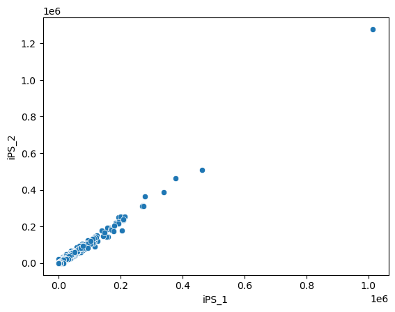

```python
# 「iPS_1」と「iPS_2」の遺伝子発現量を「scatterplot」として図示してみます
sns.scatterplot(
    data = df,  # データとして、log変換前の「df」を用います
    x = "iPS_1",
    y = "iPS_2",
)
```

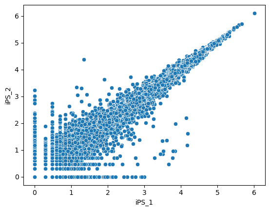

```python
sns.scatterplot(
    data = df_log,  # データとして、log変換後の「df_log」を用います
    x = "iPS_1",
    y = "iPS_2",
)
```

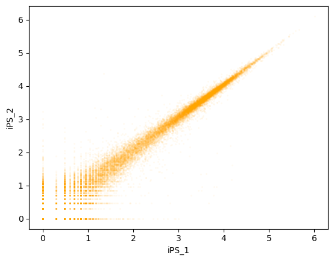

```python
# 図の設定を変えることもできます
sns.scatterplot(
    data = df_log,  # データとして、log変換後の「df_log」を用います
    x = "iPS_1",
    y = "iPS_2",
    s = 5,
    alpha = 0.05,
    color = "orange",
    linewidth = 0,
)
```

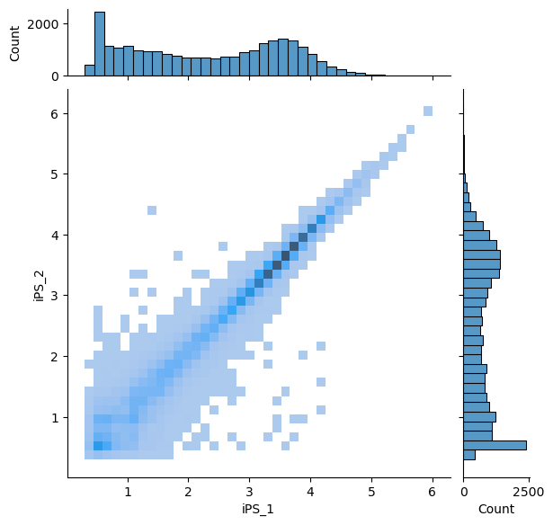

```python
# 他のタイプの図を作ることもできます
sns.jointplot(
    data = df_log.replace(0.0, np.nan),
    x = "iPS_1",
    y = "iPS_2",
    kind = "hist",
    hue_norm = [0, 100],
    marginal_ticks = True,
    dropna = True,
)
```

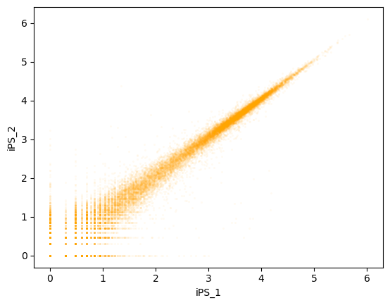

```python
#　図を保存します
sns.scatterplot(
    data = df_log,
    x = "iPS_1",
    y = "iPS_2",
    s = 5,
    alpha = 0.05,
    color = "orange",
    linewidth = 0,
)

plt.savefig("plot1.pdf")  # jupyter notebookの場合は、同じセルで実行する必要がある
```

## 7. まとめ

- pandasで「データフレーム」を作り、データを管理し、データQCなどを行うことができます
- numpyを使うと、log変換などの数値計算ができます
- seabornとmatplotlibを使うと、図を書いて保存することができます